# findings_report

### You consider investing your money in peer-to-peer loans? Here are 10 risk assessments you should keep in mind.

**[Prosper](https://www.prosper.com/)** is a peer-to-peer loan marketplace where you can either borrow money or invest yours in other peoples loans. Borrowers get a fixed rate, fixed term loan between 1,000\$ and 35,000\$. Individuals and institutions on the other hand can invest in those loans and earn returns (in case the loan does not default or get charged off).

I queried more than **20 metrics on 105,000 loan commissions between 2006 and 2014 for this project**. The dataset was cleaned thoroughly whereby multiple quality and tidiness issues were adressed to have a dataset which is as reliable as possible to work with. In case you're interested in the exact wrangling efforts performed, please check out the `wrangle_exploration_act.ipynb` notebook which describes them in detail.

Let's get started and check the mean return on investment you can expect for each borrower credit score group.

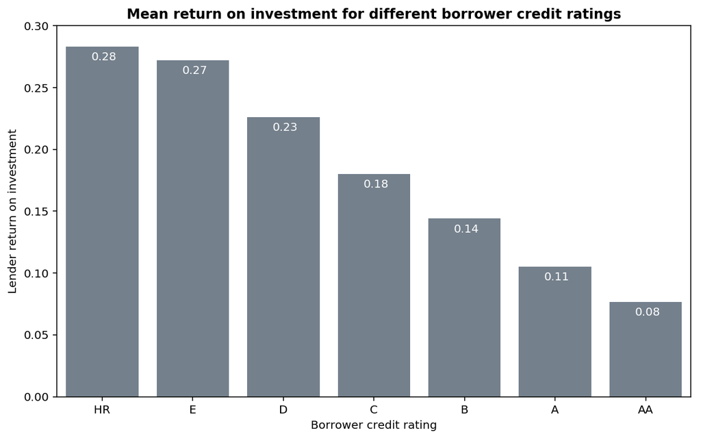

The x-axis of the above graph depicts the borrowers credit rating, the y-axis the average return on investment the lender can expect. Like expected, investments in loans with a weak rating are most likely a lot riskier and therefore yield a higher possible return. The average return on investment (ROI) decreases steadily with investments in AA rated loans yielding the on average lowest return (8%) for investors.

Knowing this, let's check the **outcome probabilities for borrowers with different credit ratings**:

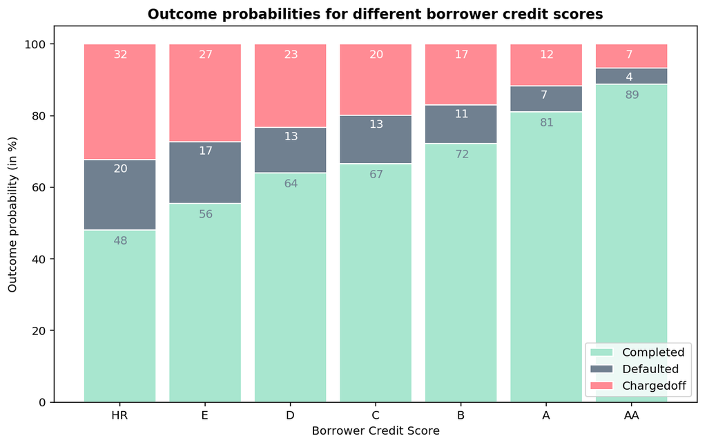

The above plot is most likely my favorite of this project. As was shown in the first graph, HR rated loans yield an average return of around 28 percent for investors. However, this graph clearly highlights the risk of weak rated loans as only 48 percent of HR rated loans were payed back properly. 20 percent of all HR rated loans are listed as defaulted, meaning that the borrower failed to make payments for a period of 1-120 days and theres uncertainty to whether he will continue to make payments or whether the loan needs to be charged off. 32 percent of all HR rated loans defaulted for at least 121 days and thus eventually had to get charged off, meaning that there was no longer any reasonably expection for the loan to be ever payed back. On the other end of the spectrum, AA rated loans were payed pack with a probability of 89 percent.

Now setting the first two graphs into perspective, here's a graph with the **risk adjusted expected ROI** (for best and worst case) if you were to solely base your investment decision on the borrowers credit score. I defined the **best case** risk adjusted ROI as the average ROI (seen in graph 1) minus the probability of a loan to get **charged off** (seen in graph 2) and the **worst case** adjusted ROI as the average ROI minus the probability of a loan to get **charged off or default** (all currently defaulted loans are expected to get charged off eventually in this scenario).

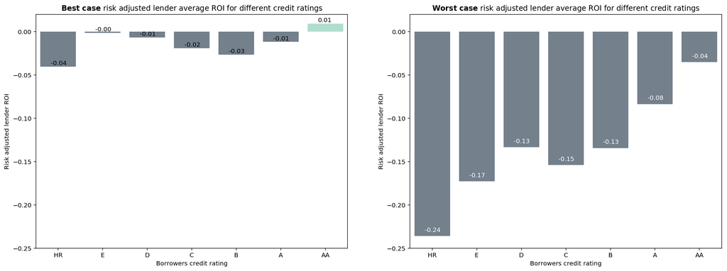

In the worst scenario (all defaulted loans getting charged off eventually), your average ROI would be a net loss of 23,5 percent for credit rating HR! Even in the best case scenario, the expected risk adjusted ROI remains negative. For me, this clearly raises a red flag on any HR rated loan. On the other end of the spectrum, your worst case expected ROI would be -3.5 percent for AA rated loans and 1 percent for the best case scenario. Anything but great but way better compared to high risk loans. For the worst case scenario, the ROI moves closer to the breakeven point with the credit rating increasing. For the best case scenario its not so clear. Anyway, the truth is most likely somewhere between both graphs and your ROI is most likely going to be negative if you base your investment decision solely on the credit rating.

**Two key takeaways so far:**

- Avoid weak rated loans at any cost, credit default rates are way higher than possible returns.
- You cannot base your decision solely on credit ratings as the average ROI is negative for all ratings except the best case scenario for AA.

So let's explore further variables to see if any other red flags turn up!

**Here's a graph depicting the probability of a loan to default for different reasons why the borrower took a loan.**

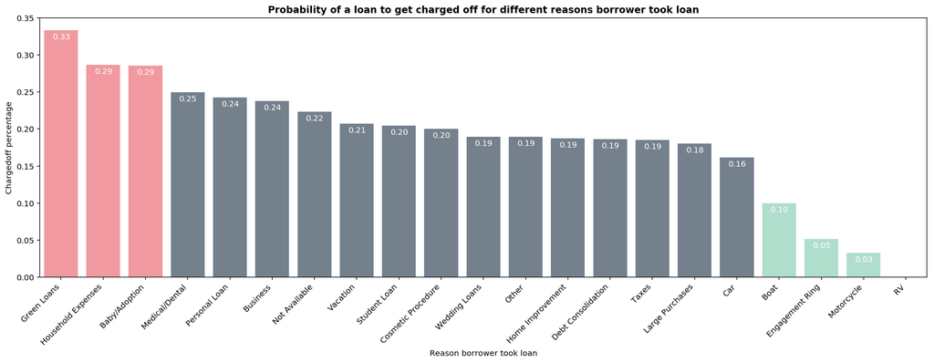

You better avoid those green loans, household expenses and borrowers with recent offspring (sad as it is). Almost one in three of these loans won't ever be payed back. On the other end of the spectrum, boats, engagement rings and motorcycles are for whatever reason the most reliable categories considering the chargedoff percentage. One thing that surprised me though is the chargedoff rate of debt consolidation dating at just 19 percent. I expected this category to be ranked a lot higher since I thought people who already were in debt would be a lot less likely to pay back their loan. Seems like I can't always trust my intuition, I guess that's we do these anlyses in the first place.

**Next variable: The borrowers occupation**

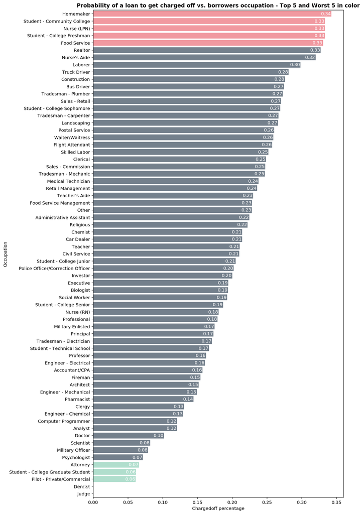

Homemakers, community college students and nurses are currently the occupations with the lowest payback rate. More shocking, 50 percent of all occupations are associated with a chargedoff rate of 20 percent or more. On the other hand, dentists and judges currently have a clean slate! Not a single loan taken by one of them was ever charged off.

**This observation raises the question if borrowers working in fields associated with high payback rates receive lower interest rates, so let's check on that.**

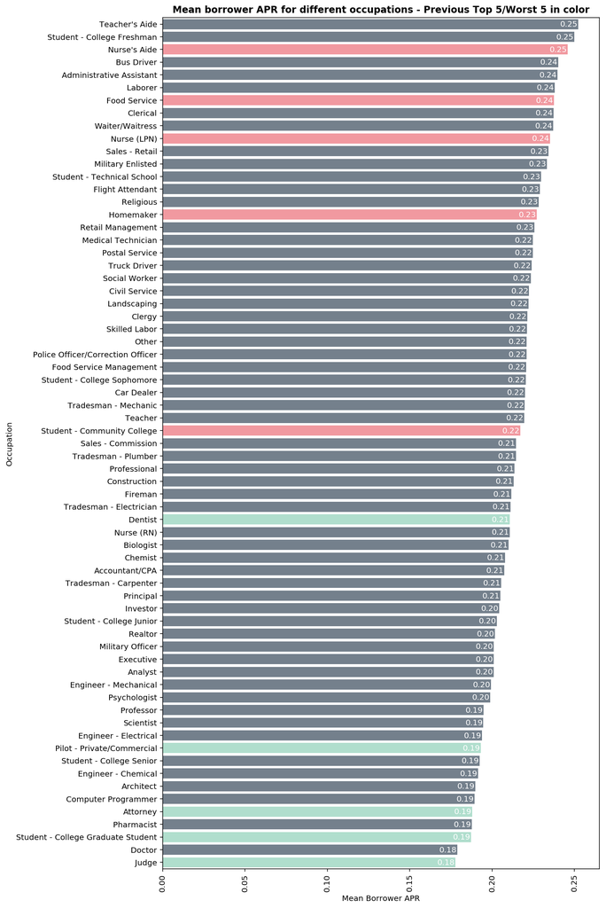

The borrowers APR is not always in line with with my previous ranking of them on the chargedoff rate scala. Dentists seem to be an interesting occupation group to look out for. They get charged and APR just above average while yet not a single one had their loan ever charged off.

People can change and you shouldn't judge anyone on their past. But I'm not sure whether this worldly wisdom also translates to a borrowers past of delinquencies (Puh, what a transition to the next characteristic).

**Are borrowers with (multiple) delinquencies in the past less likely to pay back their loan now?**

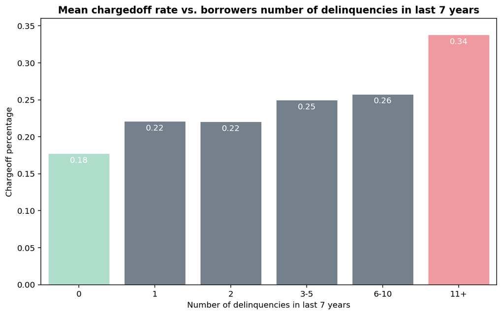

It looks like a borrowers past can hint an insight towards his current reliability. Borrowers who did not have a single delinquency in the past 7 years have the on average savest investment as they have the on average lowest chargedoff rate, meaning they are most likely to pay back their loans. The probability of the current loan to get charged off increases with the number of past delinquencies increasing. You better make sure to avoid borrowers with 11 or more delinquencies in the past as their loans get charged off with a probability of 34 percent.

**Next up: The borrowers employment status:**

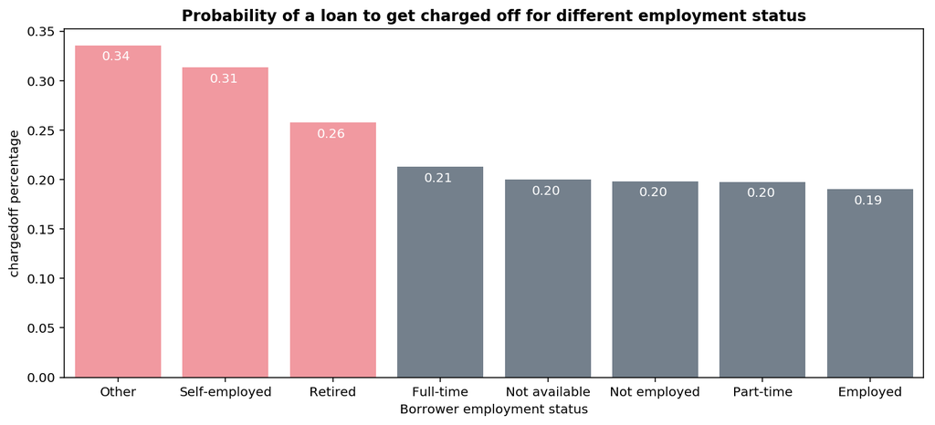

The employment status 'Other' raises a red flag for me. Seems like someone who does not want to specify his employment status is much more likely to not pay back the loan. Additionally, be aware that self-employed and retired borrowers also come with a substantial risk increase.

**Finally, let's check whether the borrowers likelihood to pay back a loan varies for different states:**

[interactive chart not shown]

They do, the above map depicts many different shades of purple for different chargedoff percentages. Between the most reliable state Wyoming and the least reliable state Maine lies a mean difference of 20 percentage points! Besides that, there is no clear east-west of north-south difference visible.

We're almost at the end, there's just one more plot I want to show you because I consider this trend important. The following graph depicts the change in difference between the interest rate the borrower has to pay for the loan and the interest rate Prosper offers you for your investment. This exact difference is Prospers profit for every loan they conveyed on their platform.

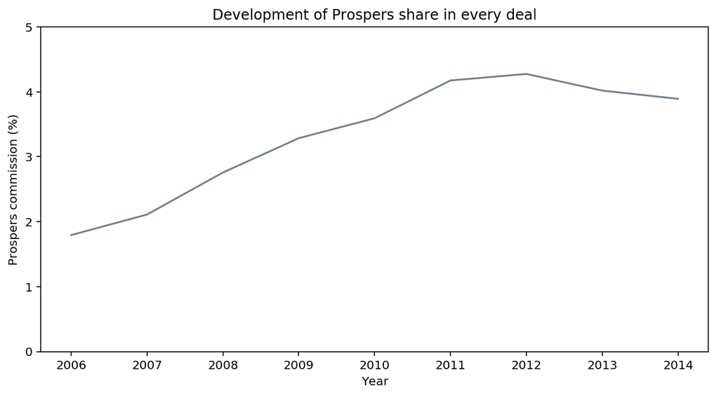

See why I told you it's important? Prospers commission fee for every deal started at just under 2 percentage points in 2006 and increased to 4 percentage points from 2011 onwards, meaning Prosper increased their profit for every commission by 100 percent. This increase in contribution margin is of course a delightful trend if your working at Prosper, however, for us investors in peer-to-peer loans it's not so good news since this decreases our risk compensation.

**Conclusion.** First of all congratulations for making it this far, you are an awesome reader! We've discovered a ton of useful insights about the peer-to-peer loan market. We've seen that a borrowers credit score gives a first good impression on his likelihood of paying back the loan. However the mean chargedoff rate was also shown to vary widely across other factors, namely the borrowers occupation, past delinquencies, his employment status and his state of origin. So next time you invest your money in peer-to-peer loans, be sure to check on all categories to improve your chances of getting a good return.